# Visualizing Educational Attainment in NYC with Dot-Density Map

Alex Henoumont

## Abstract

Dot density map is a useful tool for businesses, governments and community leaders to describe populations over time. By collecting data from the American Community Survey, the attributes of the populations can be plotted onto the map and help decide where products and services will produce the greatest benefits. Below describes the process of creating a dot density map to describe the distribution of educational attainment in New York City.

From the map below we see that areas with the highest educational attainment are within Manhattan (below Harlem), Downtown Brooklyn and Williamsburg. Generally educational attainment appears to diminish as distance increases from these areas. It is also worth noting that the Lower East Side has lower educational attainment that its adjacent neighborhoods.

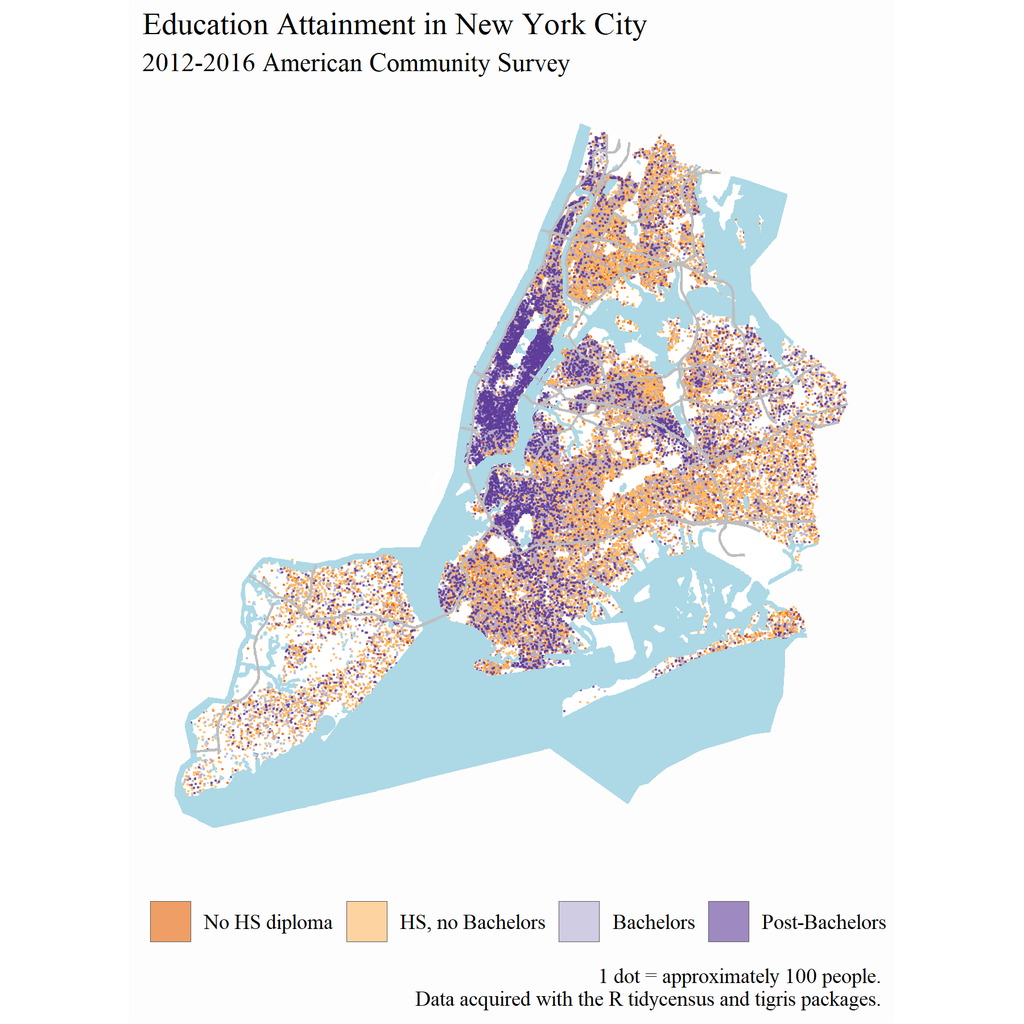

Education in NYC

## NYC education by tract from the 2016 5yr American Community Survey

```r
library(tidycensus)
library(tidyverse)
library(tigris)
library(sf)
library(RColorBrewer)
```

# Find The Data

Below, the varables are loaded into a dataframe where only 29 distinct table contain the keywords ‘Educational Attainment’. B15003: EDUCATIONAL ATTAINMENT FOR THE POPULATION 25 YEARS AND OVER apears to be the best fit. This table will be used for our analsis.

```r
v16 <- load_variables(2016, "acs5", cache = TRUE)
v16 %>%
    mutate(table = str_extract(name, "^.+_")) %>%
    filter(str_detect(concept, "EDUCATIONAL ATTAINMENT")) %>%
    select(table, concept) %>% distinct %>% print(n = Inf)
```

```
## # A tibble: 29 x 2
##    table     concept
##    <chr>     <chr>
##  1 B06009_   PLACE OF BIRTH BY EDUCATIONAL ATTAINMENT IN THE UNITED STATES
##  2 B06009PR_ PLACE OF BIRTH BY EDUCATIONAL ATTAINMENT IN PUERTO RICO
##  3 B07009_   GEOGRAPHICAL MOBILITY IN THE PAST YEAR BY EDUCATIONAL ATTAINM~
##  4 B07009PR_ GEOGRAPHICAL MOBILITY IN THE PAST YEAR BY EDUCATIONAL ATTAINM~
##  5 B07409_   GEOGRAPHICAL MOBILITY IN THE PAST YEAR BY EDUCATIONAL ATTAINM~
##  6 B07409PR_ GEOGRAPHICAL MOBILITY IN THE PAST YEAR BY EDUCATIONAL ATTAINM~
##  7 B13014_   WOMEN 15 TO 50 YEARS WHO HAD A BIRTH IN THE PAST 12 MONTHS BY~
##  8 B14005_   SEX BY SCHOOL ENROLLMENT BY EDUCATIONAL ATTAINMENT BY EMPLOYM~
##  9 B15001_   SEX BY AGE BY EDUCATIONAL ATTAINMENT FOR THE POPULATION 18 YE~
## 10 B15002_   SEX BY EDUCATIONAL ATTAINMENT FOR THE POPULATION 25 YEARS AND~
## 11 B15003_   EDUCATIONAL ATTAINMENT FOR THE POPULATION 25 YEARS AND OVER
## 12 B16010_   EDUCATIONAL ATTAINMENT AND EMPLOYMENT STATUS BY LANGUAGE SPOK~
```

[output cut: 17 more lines]

```r
state <- 'NY'
county <- c('new york', 'kings', 'queens', 'bronx', 'richmond')
#Using key words and regex to recode variables
##Table B15003: Educational Attainment for individuals 25 and over
Education <- get_acs("tract", table = "B15003", cache_table = TRUE,
               geometry = TRUE, state = state, county = county,
               year = 2016, output = "tidy", key = api_key)
head(Education)
```

```
## Simple feature collection with 6 features and 5 fields
## geometry type:  MULTIPOLYGON
## dimension:      XY
## bbox:           xmin: -73.89987 ymin: 40.78536 xmax: -73.86712 ymax: 40.80121
## epsg (SRID):    4269
## proj4string:    +proj=longlat +datum=NAD83 +no_defs
##         GEOID                                   NAME   variable estimate
## 1 36005000100 Census Tract 1, Bronx County, New York B15003_001     5322
## 2 36005000100 Census Tract 1, Bronx County, New York B15003_002       71
## 3 36005000100 Census Tract 1, Bronx County, New York B15003_003        0
## 4 36005000100 Census Tract 1, Bronx County, New York B15003_004        0
## 5 36005000100 Census Tract 1, Bronx County, New York B15003_005       17
## 6 36005000100 Census Tract 1, Bronx County, New York B15003_006        9
##   moe                       geometry
## 1 303 MULTIPOLYGON (((-73.8925 40...
## 2  43 MULTIPOLYGON (((-73.8925 40...
## 3  16 MULTIPOLYGON (((-73.8925 40...
## 4  16 MULTIPOLYGON (((-73.8925 40...
## 5  21 MULTIPOLYGON (((-73.8925 40...
## 6  15 MULTIPOLYGON (((-73.8925 40...
```

## Data Manipulation

The educational attainment is retrieved from table ‘B15003’, however, the ACS has coded 25 levels of educational attainment, B15003_001 through B15003_025. Our next step should aggregate the data into four groups, ‘No HS diploma’, ‘HS, no Bachelors’, and ‘Post-Bachelors’. - ‘B15003_001’ is ommited as it contains the estimated total population for that area. - ‘B15003_002’‘-’‘through ’B15003_016’ includes observations without HS diplomas; - ‘B15003_17’ through ‘B15003_21’ includes HS diploma and no Bachelors degree; - ‘B15003_22’ includes Bachelors degree; and - ‘B15003_23’ through ’B15003_025 includes post-Bachelors degree.

```r
#ACS code values
v16 %>% filter(str_detect(name, "B15003_"))
```

```
## # A tibble: 25 x 3
##    name     label                     concept
##    <chr>    <chr>                     <chr>
##  1 B15003_~ Estimate!!Total           EDUCATIONAL ATTAINMENT FOR THE POPUL~
##  2 B15003_~ Estimate!!Total!!No scho~ EDUCATIONAL ATTAINMENT FOR THE POPUL~
##  3 B15003_~ Estimate!!Total!!Nursery~ EDUCATIONAL ATTAINMENT FOR THE POPUL~
##  4 B15003_~ Estimate!!Total!!Kinderg~ EDUCATIONAL ATTAINMENT FOR THE POPUL~
##  5 B15003_~ Estimate!!Total!!1st gra~ EDUCATIONAL ATTAINMENT FOR THE POPUL~
##  6 B15003_~ Estimate!!Total!!2nd gra~ EDUCATIONAL ATTAINMENT FOR THE POPUL~
##  7 B15003_~ Estimate!!Total!!3rd gra~ EDUCATIONAL ATTAINMENT FOR THE POPUL~
##  8 B15003_~ Estimate!!Total!!4th gra~ EDUCATIONAL ATTAINMENT FOR THE POPUL~
##  9 B15003_~ Estimate!!Total!!5th gra~ EDUCATIONAL ATTAINMENT FOR THE POPUL~
## 10 B15003_~ Estimate!!Total!!6th gra~ EDUCATIONAL ATTAINMENT FOR THE POPUL~
## # ... with 15 more rows
```

```r
Education <- Education %>%
  mutate(id = str_extract(variable, "[0-9]{3}$") %>% as.integer) %>%
  # variable 1 is the "total", which is just the sum of the others
  filter(id > 1) %>%
  mutate(education =case_when(
    id %>% between(2, 16) ~ "No HS diploma",
    id %>% between(17, 21) ~ "HS, no Bachelors",
    id == 22 ~ "Bachelors",
    id > 22 ~ "Post-Bachelors"
  )) %>%
  group_by(GEOID, education) %>%
  summarise(estimate = sum(estimate))

Education
```

```
## Simple feature collection with 8668 features and 3 fields (with 4 geometries empty)
## geometry type:  GEOMETRY
## dimension:      XY
## bbox:           xmin: -74.25609 ymin: 40.4961 xmax: -73.70002 ymax: 40.91758
## epsg (SRID):    4269
## proj4string:    +proj=longlat +datum=NAD83 +no_defs
## # A tibble: 8,668 x 4
## # Groups:   GEOID [2,167]
##    GEOID    education   estimate                                   geometry
##    <chr>    <chr>          <dbl>                             <POLYGON [Â°]>
##  1 3600500~ Bachelors         35 ((-73.8925 40.80121, -73.87226 40.79499, ~
##  2 3600500~ HS, no Bac~     2105 ((-73.8925 40.80121, -73.87226 40.79499, ~
##  3 3600500~ No HS dipl~     3141 ((-73.8925 40.80121, -73.87226 40.79499, ~
##  4 3600500~ Post-Bache~       41 ((-73.8925 40.80121, -73.87226 40.79499, ~
##  5 3600500~ Bachelors        412 ((-73.86522 40.81453, -73.86425 40.81466,~
##  6 3600500~ HS, no Bac~     2079 ((-73.86522 40.81453, -73.86425 40.81466,~
##  7 3600500~ No HS dipl~      799 ((-73.86522 40.81453, -73.86425 40.81466,~
##  8 3600500~ Post-Bache~      203 ((-73.86522 40.81453, -73.86425 40.81466,~
##  9 3600500~ Bachelors        593 ((-73.8587 40.8154, -73.85778 40.81553, -~
## 10 3600500~ HS, no Bac~     2529 ((-73.8587 40.8154, -73.85778 40.81553, -~
## # ... with 8,658 more rows
```

## Generating the dots

```r
# Generate dots, create a group column, and group by group column
split <- Education %>%
  filter(estimate > 0) %>%
  split(.$education)

generate_samples <- function(data)
  suppressMessages(st_sample(data, size = round(data$estimate / 100)))

dots <- map(split, generate_samples)
dots <- imap(dots,
               ~st_sf(data_frame(education = rep(.y, length(.x))),
                      geometry = .x))
dots <- do.call(rbind, dots)

dots <- dots %>% group_by(education) %>% summarise()
dots <- dots %>%
  mutate(education = factor(
    education,
    levels = c("No HS diploma", "HS, no Bachelors",
               "Bachelors", "Post-Bachelors")))
# view how many dots are in each layer
dots %>% mutate(n_dots = map_int(geometry, nrow))
```

```
## Simple feature collection with 4 features and 2 fields
## geometry type:  MULTIPOINT
## dimension:      XY
## bbox:           xmin: -74.25436 ymin: 40.497 xmax: -73.70075 ymax: 40.91207
## epsg (SRID):    4269
## proj4string:    +proj=longlat +datum=NAD83 +no_defs
## # A tibble: 4 x 3
##   education     n_dots                                             geometry
##   <fct>          <int>                                    <MULTIPOINT [Â°]>
## 1 Bachelors      12536 (-74.2529 40.51175, -74.25232 40.50572, -74.25154 4~
## 2 HS, no Bache~  26005 (-74.25416 40.50466, -74.25382 40.51139, -74.25306 ~
## 3 No HS diploma  11338 (-74.24932 40.50713, -74.24741 40.50382, -74.24183 ~
## 4 Post-Bachelo~   8768 (-74.25436 40.50344, -74.24745 40.50772, -74.24612 ~
```

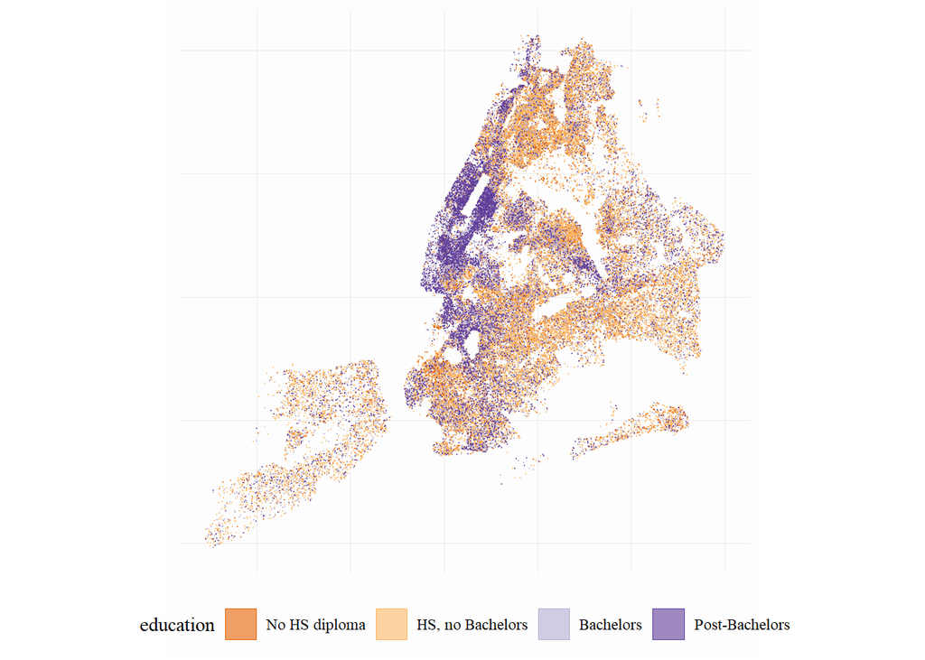

```r
#Plot the dots
theme_set(theme_minimal() +
            theme(panel.grid.major = element_line(size = 0),
                  plot.background = element_rect(fill = "#fdfdfd",
                                                 colour = NA),
                  axis.title = element_blank(),
                  text = element_text(family = "serif"),
                  axis.text = element_blank(),
                  legend.position = "bottom"))


ggplot() +
  geom_sf(data = dots, aes(color = education, fill = education), size = 0.1, alpha = 0.6)+
  scale_color_brewer(type = "div", palette = 4) +
  scale_fill_brewer(type = "div", palette = 4)
```

## Building the base map

This visualisation will be created by stacking layers on top of each other. This step will retrieve boundary, roads and water layers to help orient the reader to places on the map.

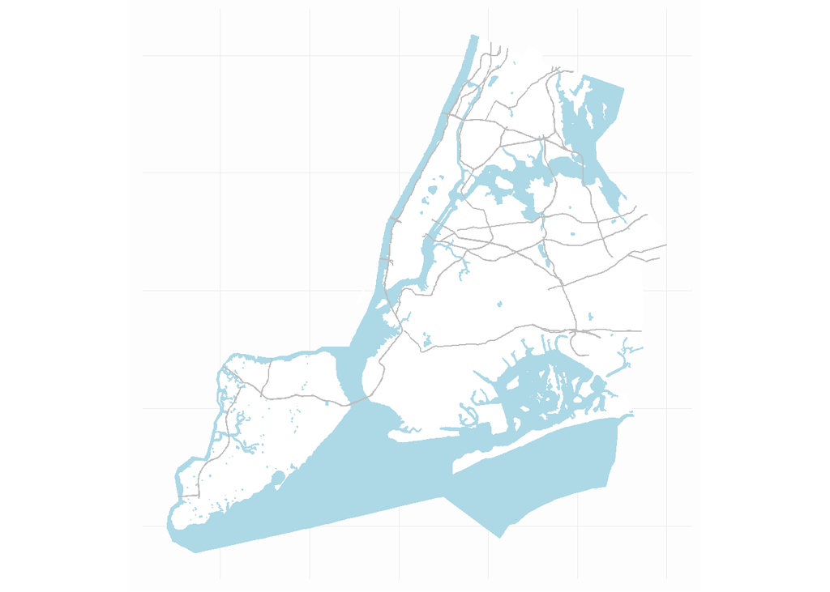

```r
#Get Map Features
#Roads
roads <- rbind_tigris(
  lapply(county, function(x) roads(state = state, county = x))
)
# Filter the NYC  roads object for major roads only
roads <- roads %>%
    filter(RTTYP %in% c("I", "S", "U"))

# Get an area water dataset for NYC
water <- rbind_tigris(
  lapply(county, function(x) area_water(state = state, county = x))
)


# Get the boundary of DC
boundary <- rbind_tigris(
  lapply(county, function(x) county_subdivisions(state = state, county = x, cb = TRUE))
)

#Check the base map
ggplot() +
  geom_sf(data = boundary, color = NA, fill = "white")+
  geom_sf(data = water, color = "lightblue", fill = "lightblue") +
  geom_sf(data = roads, color = "grey")
```

## Compiling the layers together

Now that all the layers have been collected, they must be stacked together. 1. Empty layer is first created as a placeholder, 2. Next the boundary is created with a white background, 3. Then the dots are populated, trasparency is added to account for overplotting, and the color of the dats is differentiated by educational level, 4. The water is next added to prevent the posibility of a dot accidentaly plotted over water. 5. Finally the major roadways are added to help with orienting the reader to local neighborhoods and other landmarks.

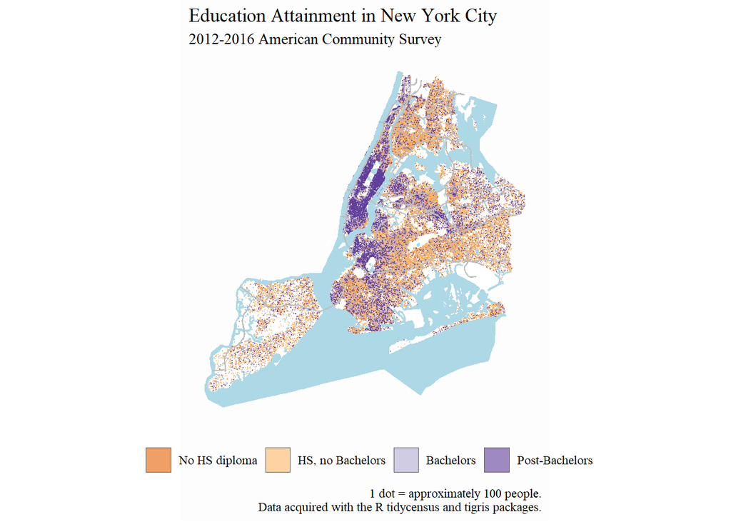

```r
nyc_education <- ggplot() +
  geom_sf(data = boundary, color = NA, fill = "white")+
  geom_sf(data = dots, aes(color = education, fill = education), size = 0.1, alpha = 0.6)+
  geom_sf(data = water, color = "lightblue", fill = "lightblue") +
  geom_sf(data = roads, color = "grey") +
  scale_color_brewer(type = "div", palette = 4) +
  scale_fill_brewer(type = "div", palette = 4) +
  # geom_sf(data = dots, aes(color = education, fill=education), size = 0.5) +
  coord_sf(crs = 26918, datum = NA) +
  # scale_color_brewer(type = "div", palette = 4) +
  # scale_fill_brewer(type = "div", palette = 4)+
  labs(title = "Education Attainment in New York City",
       subtitle = "2012-2016 American Community Survey",
       fill = "",
       caption = "1 dot = approximately 100 people.\nData acquired with the R tidycensus and tigris packages.")+
  guides(color=F)

nyc_education
```

```r
ggsave('nyc_educ.png', width= 6, height=6, units = 'in')
```